# Project ReGAIN Ex-Ante Modeling Document

Prepared by Reduce.Reuse.Grow.Inc

## Abstract

RRG has partnered with the [Philippine Eagle Foundation (PEF)](https://www.philippineeaglefoundation.org/) to conduct Project ReGAIN throughout the ancestral domain of the Obu-Manuvu on Mindano Island, Philippines. RRG and PEF have partnered to plant 4500 hectares.

## Import Libraries

```r
library(tidyverse)
library(patchwork)
library(leaflet)
library(sf)
library(purrr)
library(furrr)
library(ggtext)
library(gt)
setwd("~/scripts/rrg/r-scripts/iso")
```

# Ex-Ante Estimates of Biomass Removals

PEF will be planting secondary forests throughout degraded areas on Mindanao. [Robinson, et al.](https://www.nature.com/articles/s41558-025-02355-5) has published a global peer reviewed dataset of potential carbon removals for secondary forests. RRG is able to access this data through the Robinson, et al. [google earth engine app](https://ee-groa-carbon-accumulation.projects.earthengine.app/view/natural-forest-regeneration-carbon-accumulation-explorer) and through their [raw data](https://zenodo.org/records/15090826).

To allow for a deeper uncertainty analysis, RRG used the parameter (a, k, b) .tif files (zenodo) provided by Robinson to get parameter estimates for the prediction curves for each pixel of the project area. These estimates were then exported through this extraction script and are used to calculate estimated biomass at t with the following Chapman Richard’s equation (using 2/3 as m).

$$y = A \left( 1 - B e^{-k t} \right)^{\frac{1}{1 - m}}$$

where:

- $y$ = biomass (Mg C per ha at year t)
- $A$ = asymptote
- $B$ = integration constant
- $k$ = growth rate
- $t$ = time
- $m$ = shape parameter

#### Project Maps and CR Parameters

The map below represents the a parameters for the project region, which are the asymptotic maximum size that the system can reach under ideal conditions (max tC/ha). In the Chapman-Richards model, *a* corresponds to the theoretical upper limit of the growth process, meaning that as time approaches infinity, growth levels off at this value.

```r
philGeo <- read.csv('./csv_data/phil-cr-v2.csv') |>
  mutate(Site = if_else(Site != "", Site, Name)) |>
  select(!c(1, Name)) |>
  rename(b = b1, k = b1_1, coords = .geo) |>
  mutate(coords = str_extract(coords, "(?<=\\[)[^\\]]+(?=\\])")) |>
  separate_wider_delim(coords, delim = ",", names = c("lon", "lat")) |>
  mutate(across(c(lat, lon), as.numeric))


offset <- 0.000225
pal <- colorNumeric("YlOrRd", domain = philGeo$a)

leaflet() |>
  addTiles() |>
  addRectangles(
    data = philGeo,
    lng1 = ~lon - offset,
    lat1 = ~lat - offset,
    lng2 = ~lon + offset,
    lat2 = ~lat + offset,
    color = ~pal(a),
    fillOpacity = 0.8,
    stroke = FALSE,
    popup = ~paste("a parameter value:", a)
  ) |>
  setView(
    lng = mean(philGeo$lon),
    lat = mean(philGeo$lat),
    zoom = 12
  ) |>
  addLegend(
    pal = pal,
    values = philGeo$a,
    title = "a parameter"
  )
```

[interactive chart not shown]

#### Uncertainty in Removals and Reductions

Although the Isometric reforestation protocol provides no direct guidance on quantifying ex-ante estimates of biomass growth, the Isometric standard, [section 3.7](https://registry.isometric.com/standard/2.1#uncertainty-in-removals-and-reductions), provides three avenues for determining parameters. RRG will run models for two of the three scenarios –  
a) Conservative estimates of input parameters  
b) Monte carlo simulations

**Ex-Ante Estimates Outline**  
1) Extract a, b, k parameters for project polygons  
a) Visualize distributions for each parameter  
For conservative estimates:  
2) Use either <=16th or >=84th percentile for all parameters (whichever yields most conservative)  
For monte carlo estimates:  
3) Randomly sample from input distributions many times (e.g., n = 1,000). Select estimates <=16th percentile  
4) Scale estimates by hectares planted, carbon fraction, C02 constant, root-to-shoot ratio  
5) Use default rates for leakage, emissions, and uncertainty  
6) Calculate net ex-ante estimates

#### Parameter distributions

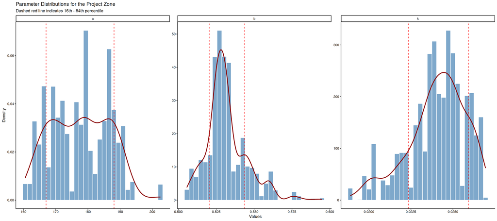

```r
quants <- tibble(
                 param = c("a", "b", "k"),
                 lower_percentile = c(quantile(philGeo$a, probs = c(0.16)), (quantile(philGeo$b, probs = c(0.16))),
                    (quantile(philGeo$k, probs = c(0.16)))),
                higher_percentile = c(quantile(philGeo$a, probs = c(0.84)), (quantile(philGeo$b, probs = c(0.84))),
                    (quantile(philGeo$k, probs = c(0.84))))
                )

philGeo |>
  pivot_longer(col = a:k, names_to = "param", values_to = "value") |>
  ggplot(aes(x = value)) +
  geom_histogram(aes(y = after_stat(density)),
                 bins = 30,
                 fill = "steelblue",
                 color = "white",
                 alpha = 0.7) +
  geom_density(color = "darkred", linewidth = 1, adjust = 4) +
  geom_vline(data = quants, aes(xintercept = lower_percentile),
             linetype = "dashed", color = "red") +
  geom_vline(data = quants, aes(xintercept = higher_percentile),
             linetype = "dashed", color = "red") +
  facet_wrap(~param, scales = "free") +
  theme_classic() +
  labs(title = "Parameter Distributions for the Project Zone", x = "Values", y="Density", subtitle = "Dashed red line indicates 16th - 84th percentile")
```

Given this analysis, the parameter, *a*, follows a uniform distribution, while both *b* and *k* follow normal distributions (slightly right and left skewed respectively). However, to use the Robinson error SD’s, RRG will utilize normal distribution simulations for all three parameters.  
Also, given the nature of the CR equation, RRG uses the following percentiles for each parameter (most conservative result):  
- *a* : 16th percentile  
- *b* : 84th percentile  
- *k* : 16th percentile

#### Monte Carlo Simulations

**Using Robinson Parameter Standard Error Estimates**

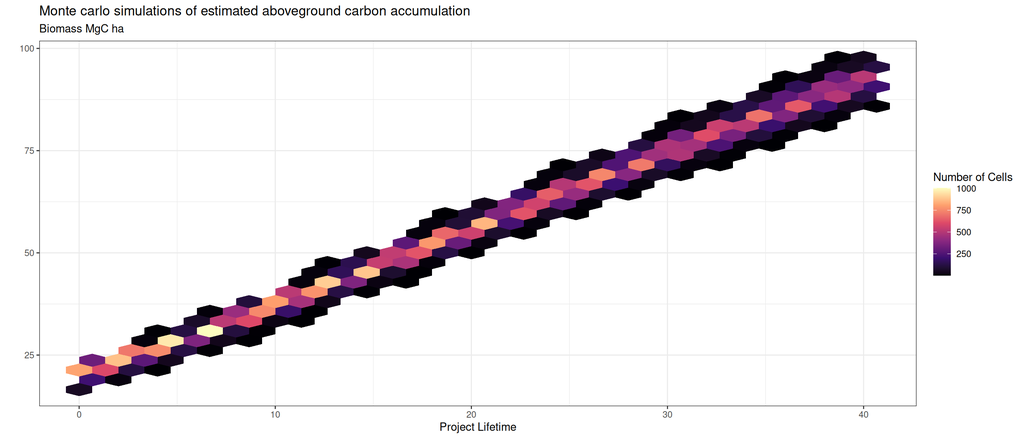

```r
error <- read.csv("./csv_data/phil-cr-error-v2.csv") |>
  mutate(Site = if_else(Site != "", Site, Name)) |>
  select(!c(1, Name)) |>
  rename(b_error = b1, k_error = b1_1, coords = .geo) |>
  mutate(coords = str_extract(coords, "(?<=\\[)[^\\]]+(?=\\])")) |>
  separate_wider_delim(coords, delim = ",", names = c("lon", "lat")) |>
  mutate(across(c(lat, lon), as.numeric))

error_param <- error |>
  select(!c(Site, lon, lat))


# set seed for reproducibility
set.seed(333)
n_sim <- 1000

mega_param <- philGeo |>
  left_join(error, by = c("Site", "lon", "lat"))

# use pmax to bound at 0

param_sim <- tibble(
  a_mc = pmax(0, rnorm(n_sim, mean = mega_param$a, sd = mega_param$a_error)),
  b_mc = pmax(0, rnorm(n_sim, mean = mega_param$b, sd = mega_param$b_error)),
  k_mc = pmax(0, rnorm(n_sim, mean = mega_param$k, sd = mega_param$k_error))
)


# apply CR function to get biomass estimates
t <- c(0:40)
cr <- function(a, b, k, t) {
  Biomass <- a * (1 - b * exp(-k * t)) ^ (1 / (1 - 0.66))
  return(Biomass)
}
full_model <- function(a_mc, b_mc, k_mc) {
  BioHa <- tibble(t = t, Bio = cr(t = t, a = a_mc, b = b_mc,
                                  k = k_mc))
  return(BioHa)
}

#results to just compare at
results_error <- future_pmap(param_sim, full_model) |> bind_rows(.id = "id")

results_error |>
  ggplot() +
  geom_hex(aes(x = t, y = Bio)) +
  theme_bw() +
  scale_fill_viridis_c(option = "A") +
  labs(title = "Monte carlo simulations of estimated aboveground carbon accumulation", fill = "Number of Cells", y = "",
       subtitle = "Biomass MgC ha", x="Project Lifetime")
```

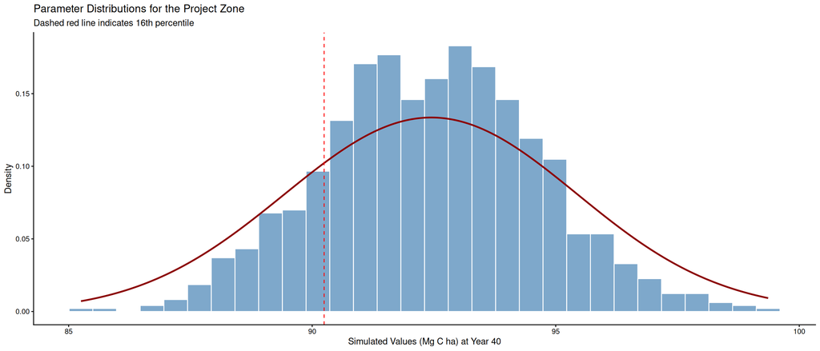

```r
t <- 40
results_t40 <- param_sim |>
  mutate(Bio = cr(a = a_mc, b = b_mc, k = k_mc, t = 40))


# find 16th/84th quartile
min_sim <- tibble(
                  lower = quantile(results_t40$Bio, probs = 0.16),
                  a = quantile(results_t40$a_mc, probs = 0.16),
                  b = quantile(results_t40$b_mc, probs = 0.84),
                  k = quantile(results_t40$k_mc, probs = 0.16)
)


results_t40 |>
  ggplot(aes(x = Bio)) +
  geom_histogram(aes(y = after_stat(density)),
                 bins = 30,
                 fill = "steelblue",
                 color = "white",
                 alpha = 0.7) +
  geom_density(color = "darkred", linewidth = 1, adjust = 4) +
  geom_vline(data = min_sim, aes(xintercept = lower),
             linetype = "dashed", color = "red") +
  theme_classic() +
  labs(title = "Parameter Distributions for the Project Zone", x = "Simulated Values (Mg C ha) at Year 40", y="Density", subtitle = "Dashed red line indicates 16th percentile")
```

##### Final Parameter Exports

```r
sim_export <- tibble(
                  a = quantile(param_sim$a_mc, probs = 0.16),
                  b = quantile(param_sim$b_mc, probs = 0.84),
                  k = quantile(param_sim$k_mc, probs = 0.16)
)
sim_export |>
  gt()
```

| a | b | k |
| --- | --- | --- |
| 184.6442 | 0.5348524 | 0.02172304 |

#### Growth Curves for the Project Zone

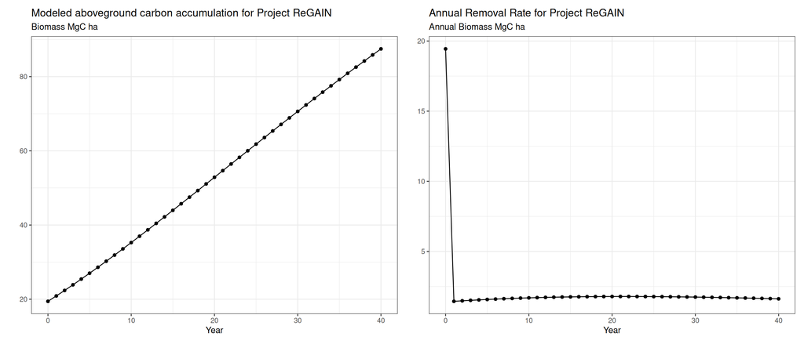

```r
df_curves <- tibble(
    Year  = 0:40,
    Monte = cr(a = sim_export$a[[1]],
               b = sim_export$b[[1]],
               k = sim_export$k[[1]],
               t = Year)
  ) |>
  mutate(Monte_rate = c(Monte[1], diff(Monte)))


p1 <- df_curves |>
  ggplot(aes(x=Year, y = Monte)) +
  geom_point() +
  geom_line() +
  theme_bw() +
  labs(title = "Modeled aboveground carbon accumulation for Project ReGAIN", color = "", y = "", subtitle = "Biomass MgC ha", x="Year")

p2 <- df_curves |>
  ggplot(aes(x=Year, y=Monte_rate)) +
  geom_point() +
  geom_line() +
  theme_bw() +
  labs(title = "Annual Removal Rate for Project ReGAIN", color = "", linetype = "", y = "", subtitle = "Annual Biomass MgC ha", x="Year")

p1 + p2
```

### Project Timeline Assumptions

These assumptions can be updated given new information.  
- Project Time Period: **2024-2064**  
- Planting Time Period: **2024-2030** (need schedules from PEF, [planting logs here](https://docs.google.com/spreadsheets/d/1OgfzW679wY32_994kkzQF6qOeARioZwA/edit?gid=1031012934#gid=1031012934))

Planting will cover ~1500 ha in instance 1 and ~3000 ha in instance 2. We can break it into seven cycles:

RRG doesn’t have concrete forecast schedules for instance 2 from PEF. For models, RRG assumes the ~3000 ha will be planted evenly throughout 2028, 2029 and 2030.  
- **Cycle 5**: 1000 ha planted throughout 2028  
- **Cycle 6**: 1000 ha planted throughout 2029  
- **Cycle 7**: 1000 ha planted throughout 2030

### Biomass Scaling

**Aboveground**

The Robinson, et al. study quantifies potential aboveground carbon gains for secondary forests on the hectare scale. Their estimates already include Mg C, so, to quantify CO2e Aboveground ([equation 15](https://registry.isometric.com/protocol/agroforestry/1.0#calculation-of-coe-3)), RRG uses the following equation:

$$CO2e AGB (t) = {\frac{44}{12}} * Mg AGB C (t)$$

where:

- $t$ = time
- $44/12$ = ratio of C mass to Co2 mass
- $Mg AGB C$ = conservative curve taken from Robinson study

**Belowground**  
To quantify the belowground biomass, RRG uses [equation 17](https://registry.isometric.com/protocol/agroforestry/1.0#calculation-of-coe-4). Per Isometric guidelines, RRG first conducted a literature review of google scholar to determine root to shoot ratios for agroforestry systems in the Philippines. Search terms included “root to shoot ratio philippines agroforestry”, “root to shoot ratio philippines”. Results provided data on species’ specific root to shoot ratios, but none for the region as a whole. Because the ex-ante forecasts are not species specific, RRG will use table 4.4 provided by the [IPCC](https://www.ipcc-nggip.iges.or.jp/public/2019rf/pdf/4_Volume4/19R_V4_Ch04_Forest%20Land.pdf), where the project zone is tropical rainforest indicated by [UN mapping](https://data.apps.fao.org/catalog/dataset/2fb209d0-fd34-4e5e-a3d8-a13c241eb61b/resource/87db158f-1b31-40a1-b76c-8d3964607158). In the future, once field inventories have begun, RRG will conduct a species’ specific root-to-shoot literature review.

$$CO2e BGB (t) = CO2e AGB (t) * RS$$

where:

- $t$ = time
- $CO2e BGB$ = total carbon stored in belowground biomass
- $RS$ = dimensionless root to shoot ratio - 0.325

**Total CO2e Stored**  
The total amount of CO2 stored from an agroforestry project is calculated as:

$$CO2e Stored (t) = CO2e AGB (t) + CO2e BGB (t)$$

where:

- $t$ = time
- $CO2e BGB$ = total carbon stored in belowground biomass
- $CO2e AGB$ = total carbon stored in aboveground biomass
- $CO2e Stored$ = total carbon stored in both biomass pools

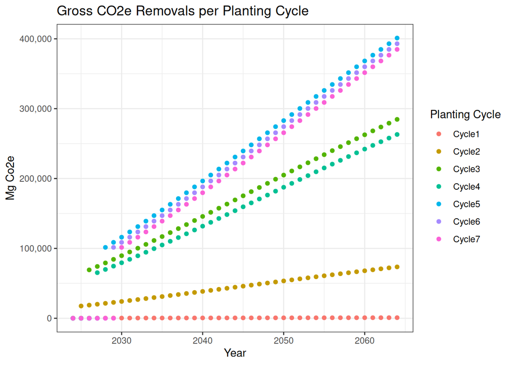

```r
pef_logs <- read.csv('csv_data/pef_log.csv')
pef_logs1 <- pef_logs[-1,] |>
  mutate(pDate = ymd(End.Date.of.Planting.Event)) |>
  rename(area = 5) |>
  select(Site.Name, pDate, area) |>
  mutate(year = year(pDate)) |>
  group_by(year) |>
  summarize(total_ha = sum(area, na.rm = TRUE))


# create function for later
growth_curve <- function(age, ha) {
  biomass <- ((sim_export$a * (1 - sim_export$b * exp(-sim_export$k * age)) ^ (1 / (1 - 0.66)) * ha) * 44/12) + (((sim_export$a * (1 - sim_export$b * exp(-sim_export$k * age)) ^ (1 / (1 - 0.66)) * ha) * 44/12)* 0.325)
  return(biomass)
}

mega <- tibble(Year = c(2024:2064),
               Age = c(1:41),
          AreaPlanted = c(2, 173, 682.5, 643, 1000, 1000, 1000 , rep(0,34)),
          Cycle1 = growth_curve(Age, AreaPlanted[1]),
          Cycle2 = c(0, growth_curve(1:40, AreaPlanted[2])),
          Cycle3 = c(0, 0, growth_curve(1:39, AreaPlanted[3])),
          Cycle4 = c(rep(0,3), growth_curve(1:38, AreaPlanted[4])),
          Cycle5 = c(rep(0,4), growth_curve(1:37, AreaPlanted[5])),
          Cycle6 = c(rep(0,5), growth_curve(1:36, AreaPlanted[6])),
          Cycle7 = c(rep(0,6), growth_curve(1:35, AreaPlanted[7])),
          TotalRemovals = Cycle1 + Cycle2 + Cycle3 + Cycle4 + Cycle5 + Cycle6 + Cycle7)

mega_mod <- mega |>
  pivot_longer(col = Cycle1:Cycle7, names_to = "cycle", values_to = "MgCO2e")

library(scales)

mega_mod |>
  ggplot(aes(x=Year, y = MgCO2e, color = cycle)) +
  geom_point() +
  theme_bw() +
  labs(title = "Gross CO2e Removals per Planting Cycle", y = "Mg Co2e", color = "Planting Cycle") +
  scale_y_continuous(label = comma)
```

In total, RRG anticipates gross removals to be **1,801,013 Mg Co2e** at year 40.

## Project Emissions

```r
#helper for later
discount <- function(metric, scale) {
  mass <- metric * scale
  return(mass)
}

emissions <- 0.2
```

### Leakge

RRG understands that Isometric performs the leakage analysis and that leakage will be quantified at the first verification event. RRG and PEF have worked with the Obu-Manuvu to ensure that local farmers are not displaced and their productivity is not impacted from project activities. PEF and the OM will ultimately sign agreements to ensure this. Furthermore, PEF aims to prioritize planting barren, degraded land and will not plant within agricultural zones. RRG will run three leakage scenarios ~ 5%, 2% and 0%.

For now, RRG has highlighted the agricultural areas within the project zone.  
[Link to agricultural map](https://rrgslo.maps.arcgis.com/apps/instant/basic/index.html?appid=133585bb0f234a17a3b84c34a27a56dc)

### Uncertainty

RRG aims to further address uncertainty in deeper analysis, but for now RRG will utilize a blanket 10% uncertainty rate. In practice, RRG takes 10% of the total Co2e removals per year.

```r
unc <- 0.1
```

### Counterfactual

Isometric is in charge of quantifying the dynamic performance benchmark and counterfactual. The PB will most likely sway our estimates of MgC/ha. For now, RRG utilizes a 5% counterfactual.

```r
pb <- 0.05
```

## Net Carbon Removals

Per [equation 13](https://registry.isometric.com/protocol/agroforestry/1.0#calculation-of-coe-1) of the agroforestry protocol, net CO2e removals are quantified as:

$$CO2e Removal (t) = CO2e Stored (t) - CO2e Counterfactual (t) - CO2e Emissions$$

where:

- $t$ = time
- $CO2e Removal$ = total net CO2e removal, in Mg CO2e
- $CO2e Stored$ = total CO2e stored in both biomass pools, in Mg CO2e
- $CO2e Counterfactual$ = total counterfactual CO2 removed from the atmosphere and stored as organic carbon in living trees in the absence of Project activities, in Mg CO2e
- $CO2e Emissions$ = total GHG emissions (leakage + LCA), in Mg CO2e

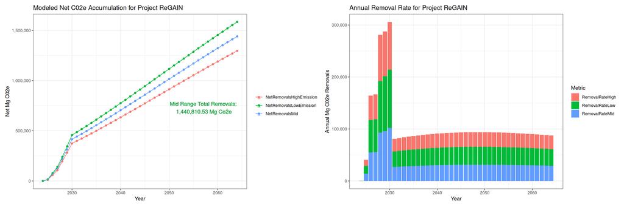

```r
mega2 <- mega |>
  select(Year, Age, TotalRemovals) |>
  mutate(LeakageHigh = c(discount(TotalRemovals[1], 0.05),
                     discount(TotalRemovals[2], 0.05),
                     discount(TotalRemovals[3], 0.05),
                     discount(TotalRemovals[4], 0.05), rep(0, 37)),
         LeakageLow = c(discount(TotalRemovals[1], 0.02),
                     discount(TotalRemovals[2], 0.02),
                     discount(TotalRemovals[3], 0.02),
                     discount(TotalRemovals[4], 0.02), rep(0, 37)),
        NetRemovalsMid = ((TotalRemovals) - discount(TotalRemovals, pb) -
                        discount(TotalRemovals, unc)  - (LeakageLow + discount(TotalRemovals, 0.05))),
        NetRemovalsHighEmission = ((TotalRemovals) - discount(TotalRemovals, 0.1) -
                        discount(TotalRemovals, unc)  - (LeakageHigh + discount(TotalRemovals, 0.08))),
        NetRemovalsLowEmission = ((TotalRemovals) - discount(TotalRemovals, 0.02) -
                        discount(TotalRemovals, unc))

)

mega2$RemovalRateMid <- c(mega2$NetRemovalsMid[1], diff(mega2$NetRemovalsMid))
mega2$RemovalRateHigh <- c(mega2$NetRemovalsHighEmission[1], diff(mega2$NetRemovalsHighEmission))
mega2$RemovalRateLow <- c(mega2$NetRemovalsLowEmission[1], diff(mega2$NetRemovalsLowEmission))

p1 <- mega2 |>
  select(Year, NetRemovalsMid, NetRemovalsHighEmission, NetRemovalsLowEmission) |>
  pivot_longer(cols = NetRemovalsMid:NetRemovalsLowEmission, names_to = "Metric", values_to = "Value") |>
  ggplot(aes(x=Year, y = Value, color = Metric)) +
  geom_point() +
  geom_line() +
  theme_bw() +
  labs(title = "Modeled Net C02e Accumulation for Project ReGAIN", color = "", y = "Net Mg C02e", x="Year") +
  geom_text(aes(x = 2057, y = 730000, label = paste("Mid Range Total Removals:\n", format(mega2$NetRemovalsMid[41],
                                                                                big.mark = ",", nsmall = 2),
                                                    "Mg Co2e")),size=4) +
  scale_y_continuous(label = comma)

p2 <- mega2 |>
  select(Year, RemovalRateMid, RemovalRateHigh, RemovalRateLow) |>
  pivot_longer(cols = RemovalRateMid:RemovalRateLow, names_to = "Metric", values_to = "Value") |>
  ggplot(aes(x=Year, y = Value, fill = Metric)) +
  geom_bar(stat="identity") +
  theme_bw() +
  labs(title = "Annual Removal Rate for Project ReGAIN", y = "Annual Mg C02e Removals", x="Year")+
  scale_y_continuous(label = comma)


p1 + p2
```

### Model Leverage Points

RRG has run multiple model scenarios to generate a range of potential net removals. Below RRG outlines the assumptions for each model.

**Assumptions**

| Model Scenario | Leakage | Emissions | Uncertainty | Performance Benchmark |
| --- | --- | --- | --- | --- |
| Net Removals Mid | 2% | 5% | 10% | 5% |
| High Emissions | 5% | 8% | 10% | 10% |
| Low Emissions | 0% | 0% | 10% | 2% |